# Build a ggplot

Francesco Lescai

28 May 2015

# Choosing the data

We will select as data what is coming from a dataset package

```r
library(ggplot2)
library(datasets)
```

And then we will select the dataset on chicken weights, which reports the weight of different chickens at different times with different type of diet

```r
data(ChickWeight)
```

# Datasets

You can check the structure of the dataset by using

```r
str(ChickWeight)
```

```
## Classes 'nfnGroupedData', 'nfGroupedData', 'groupedData' and 'data.frame':   578 obs. of  4 variables:
##  $ weight: num  42 51 59 64 76 93 106 125 149 171 ...
##  $ Time  : num  0 2 4 6 8 10 12 14 16 18 ...
##  $ Chick : Ord.factor w/ 50 levels "18"<"16"<"15"<..: 15 15 15 15 15 15 15 15 15 15 ...
##  $ Diet  : Factor w/ 4 levels "1","2","3","4": 1 1 1 1 1 1 1 1 1 1 ...
##  - attr(*, "formula")=Class 'formula' length 3 weight ~ Time | Chick
##   .. ..- attr(*, ".Environment")=<environment: R_EmptyEnv>
##  - attr(*, "outer")=Class 'formula' length 2 ~Diet
##   .. ..- attr(*, ".Environment")=<environment: R_EmptyEnv>
##  - attr(*, "labels")=List of 2
##   ..$ x: chr "Time"
##   ..$ y: chr "Body weight"
##  - attr(*, "units")=List of 2
##   ..$ x: chr "(days)"
##   ..$ y: chr "(gm)"
```

# Datasets 2

or just by

```r
head(ChickWeight)
```

```
##   weight Time Chick Diet
## 1     42    0     1    1
## 2     51    2     1    1
## 3     59    4     1    1
## 4     64    6     1    1
## 5     76    8     1    1
## 6     93   10     1    1
```

# Building the plot

We can first observe the data using a simple plot

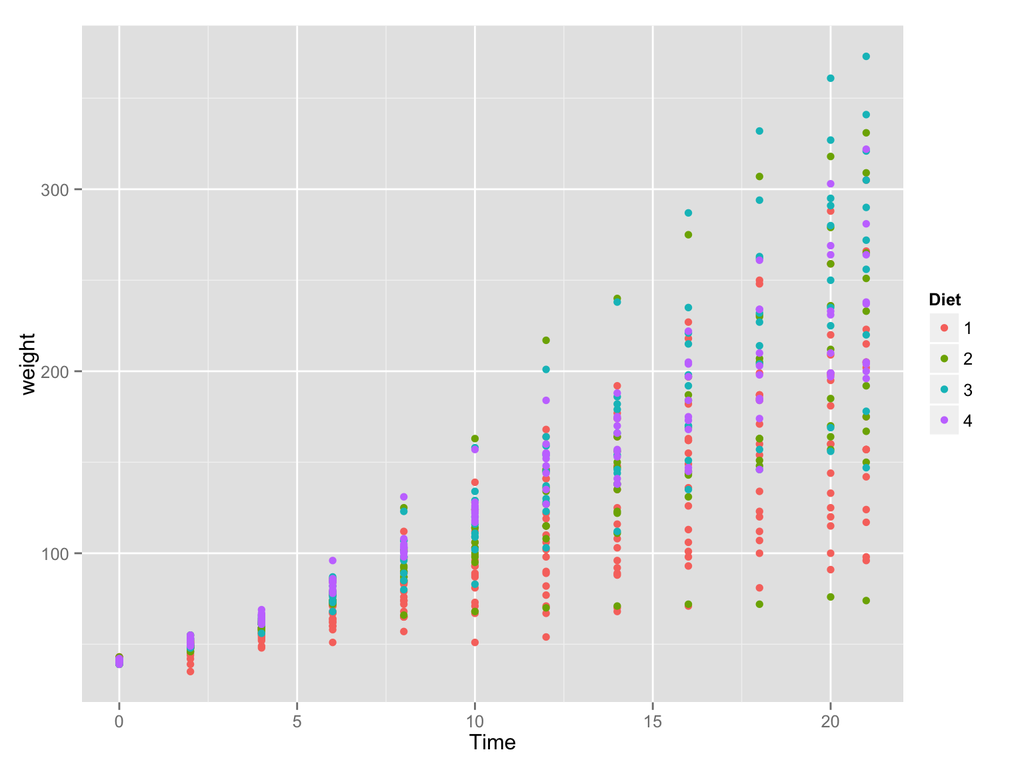

```r
ggplot(ChickWeight, aes(x=Time, y=weight, color=Diet))+geom_point()
```

which is a bit messy because at each timepoint we will have several individuals with different weights and different diets

# Building the plot 2

We can therefore use the smoothing function to estimate the trend by distinguishing the diets

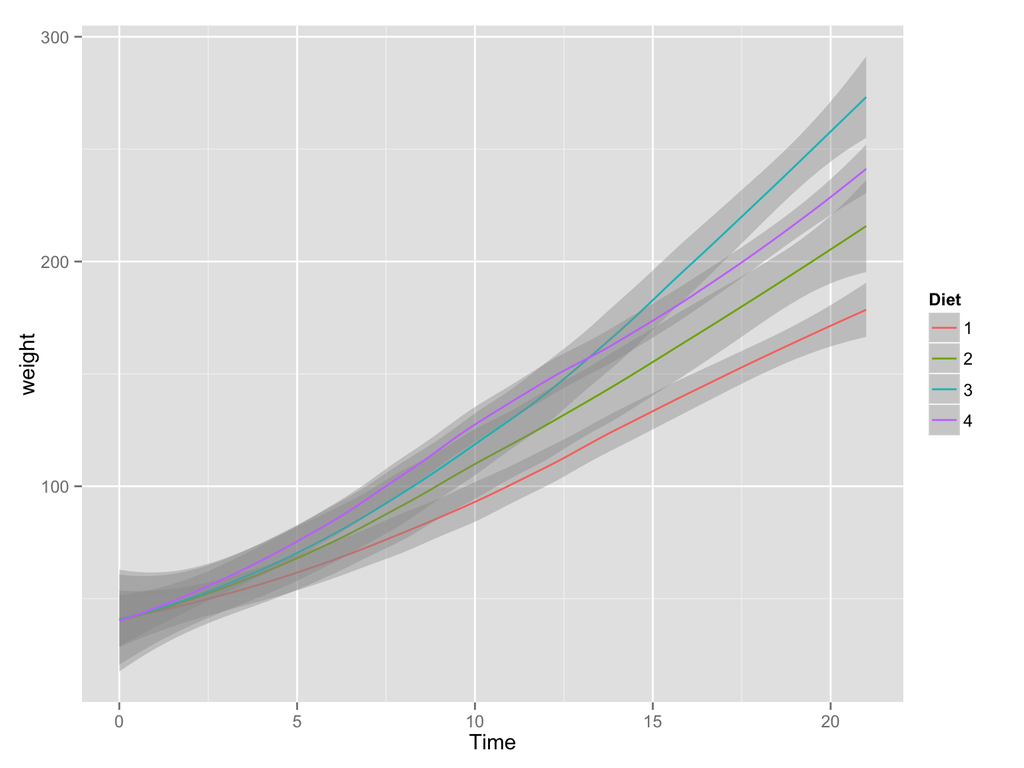

```r
ggplot(ChickWeight, aes(x=Time, y=weight, color=Diet))+geom_smooth()
```

This gives us a better idea that the diet 3 is the one that at the end seems to increase the weight of the chickens… But we want to see this better

# Scales

we can therefore use the “scales” elemeent, to change the appearance of the legend and their names, and add to the geometry some more elements

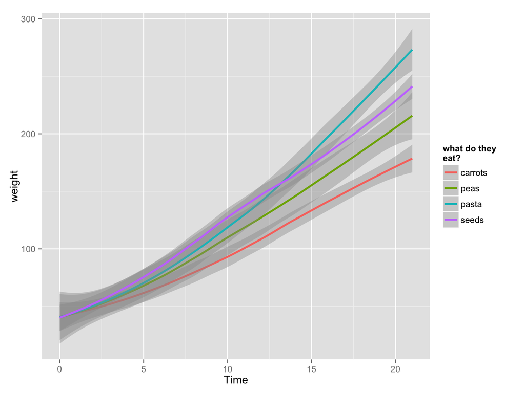

```r
ggplot(ChickWeight, aes(x=Time, y=weight, color=Diet))+
  geom_smooth(size=1)+
  scale_color_hue(
    "what do they \neat?",
    breaks=c(1,2,3,4),
    labels=c("carrots","peas","pasta","seeds")
    )
```

Et voilà